# HW 5

Denys Osmak

2024-02-21

# GITHUB: https://github.com/DenysUkr/SDS-315-GitHub-Repo/tree/0c18c7ab6aec1e9d8abd0834cfccd06012621767/Homework/HW%205

# Problem 1

```r
#importing the data
```

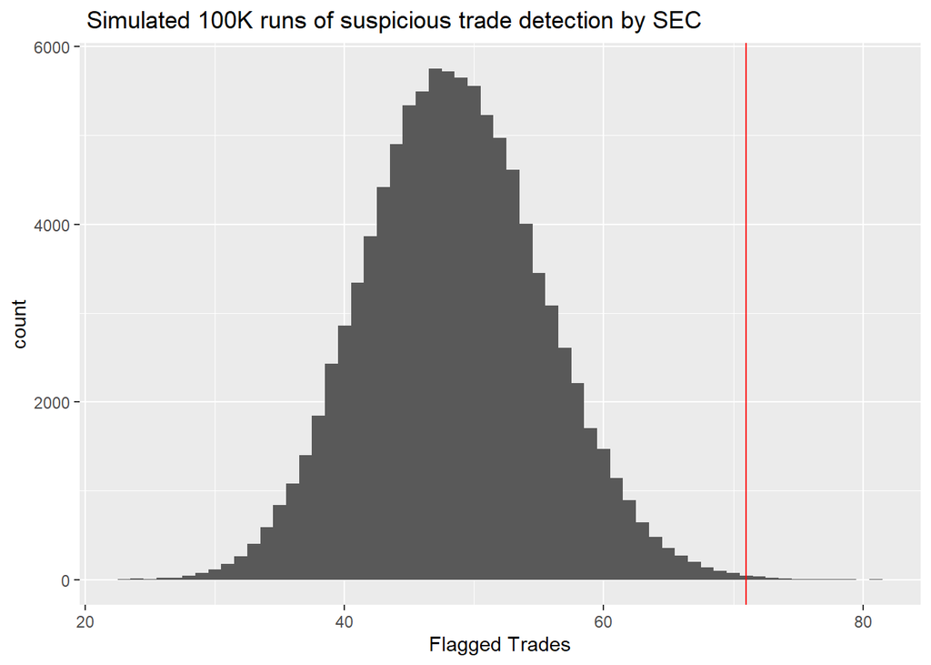

```r
# run the boot strap 100k times

pr1boot = do(100000) * nflip(n=2021, prob=0.024)

# print how many times the times there was fraud over 70 times detected (SUMMARY STATISTIC)

ggplot(pr1boot) +
  geom_histogram(aes(x=nflip), binwidth=1) +
  labs(title=" Simulated 100K runs of suspicious trade detection by SEC", x="Flagged Trades") +
  geom_vline(xintercept = 71, color = "red")
```

```r
# Find the ratio of how many times fraud was over 70 times vs total count (P-VALUE)
pr1Pvalue = count(pr1boot >= 70)/100000
```

## Conclusion:

I am testing null hypothesis where Iron Bank did not commit any illegal trades, but rather they were flagged due to pure chance. I am using the SEC reported 2.4% chance of falsely flagging a trade as suspicious. According to the Monte Carlos Simulation the p-value that was acquired from this experiment is 0.00211 meaning there is 0.211% that Iron Bank suspicious trades were flagged due to pure chance, concluding that Iron Bank was rightfyly to been flagged for suspicious trade.

# Problem 2

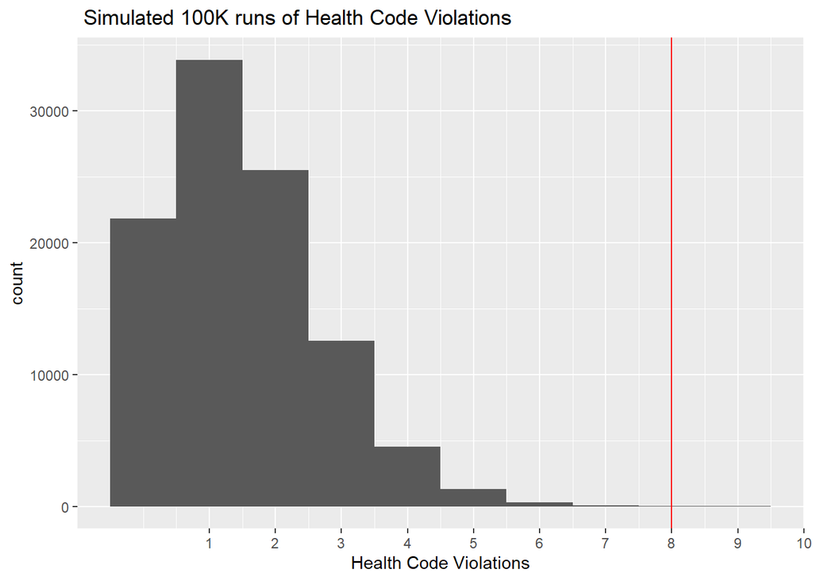

```r
# run the boot strap 100k times

pr2boot = do(100000) * nflip(n=50, prob=0.03)

# print how many times the times there was fraud over 70 times detected (SUMMARY STATISTIC)

ggplot(pr2boot) +
  geom_histogram(aes(x=nflip), binwidth = 1) +
  labs(title=" Simulated 100K runs of Health Code Violations", x="Health Code Violations") +
  geom_vline(xintercept = 8, color = "red") +
   scale_x_continuous(breaks = seq(1, 10, by = 1))
```

```r
# Find the ratio of how many times fraud was over 70 times vs total count (P-VALUE)
pr2Count = count(pr2boot >= 8)
pr2Pvalue = pr2Count/100000
```

## Conclusion:

I am testing null hypothesis where Gourmet Bites does not have any abnormal health violations, but rather they were flagged due to pure chance. I am using the Health Deperpent reported 3% chance of normal health code violations in a well maintained kitchen. According to the Monte Carlos Simulation the p-value that was acquired from this experiment is 1.2^{-4} meaning there is 0.012% that Gourmet Bites had violated health code trades due to pure chance, concluding that Gourmet Bites was rightfully to been charged with health code violations.

# Problem 3

# Pt1:

```r
# copied over from Ceaser Cipher
calculate_chi_squared = function(sentence, freq_table) {

  # Ensure letter frequencies are normalized and sum to 1
  freq_table$Probability = freq_table$Probability / sum(freq_table$Probability)

  # Remove non-letters and convert to uppercase
  clean_sentence = gsub("[^A-Za-z]", "", sentence)
  clean_sentence = toupper(clean_sentence)

  # Count the occurrences of each letter in the sentence
  observed_counts = table(factor(strsplit(clean_sentence, "")[[1]], levels = freq_table$Letter))

  # Calculate expected counts
  total_letters = sum(observed_counts)
  expected_counts = total_letters * freq_table$Probability

  # Chi-squared statistic
  chi_squared_stat = sum((observed_counts - expected_counts)^2 / expected_counts)

  return(chi_squared_stat)
}
```

```r
# import sentances
brownText = read_lines("brown_sentences.txt")

# convert all text to upper and remove all funky characters

brownText = gsub("[^A-Za-z]", "", brownText)
brownText = toupper(brownText)

# import the frequancy table from Guttemburg exercise that we did earlier
letterFreq = read.csv("letter_frequencies.csv")

# Use the caclulate chi function in a for loop for all of the senteances from Brown Text
chiBrownTable = data.frame(chiSquare = c())

for (sentance in brownText)
{
  chiBrownTable = append(chiBrownTable, calculate_chi_squared(sentance, letterFreq))
  #print(sentance)
  #print(calculate_chi_squared(sentance, letterFreq))

}

chiBrownTable
```

[output not shown]

[output cut: 170179 more lines]

[output not shown]

```r
# print out a hisogram graph to see the normal distribution of all chi suqared values for the Brown text

#ggplot(chiBrownTable) +
  #geom_histogram(aes(x=Value), binwidth=1) +
  #labs(title=" Simulated 100K runs of suspicious trade detection by SEC", x="Flagged Trades")
```